# GEO 348 Final Project Chicago Vaccination

## GEO 348 Final Project: Chicago COVID-19 Vaccinations

### Danyah Khan

The covid-19 pandemic continues to affect the global population. It has had signicant economic and societal impacts and has affected all aspects of life. Common preventive measures that have been taken include social distancing, lockdowns, quarantines, travel restrictions, face mask mandates, self-isolation. So, becoming vaccinated has become increasingly imporant. The covid-19 vaccines (pfizer, moderna, astraZeneca, etc.) decrease the risk of contracting covid-19 and protects individuals as well as anyone they are in contact with.

Reciving the vaccine has importance in other areas of life. This can include traveling to different coutries where a covid-19 vaccine is required or a negative covid-19 test. Universities throughout the U.S. also require students to be vaccinated before coming to in person classes. One example of this is DePaul Univesity, where we as students must upload the vaccination card in order to be on campus for the 2021-22 academic year.

There are a number of reasons that prevent people from getting vaccinated. In the article, "The 6 reasons Americans aren’t getting vaccinated", the author highlights a number of reasons why people in America are not getting vaccinated. These reasons include: lack of access to vaccines, a refusal to see Covid-19 as a threat, concern about the vaccines’ side effects, little trust in the vaccines or the institutions behind them, and belief in at least one of several different conspiracy theories.

The pandemic has raised underlying issues of health equity, racial discrimination, geographic discrimination, etc. The purpose of this project is to learn more about the socio-economic disparities throughout Chicago as well as examinig the covid-19 vaccination completion rates as they differ by zip code areas in Chicago. This will provide an insight on how vaccination completions differ by these different areas.

Article link: https://www.vox.com/2021/6/2/22463223/covid-19-vaccine-hesitancy-reasons-why

```python
# Importing libraries
import numpy as np
import pandas as pd
import matplotlib.pyplot as plt
import geopandas as gpd
import seaborn as sns
import scipy.stats
```

### Geospatial data

The covid-19 vaccination completion rate contains data as of May 2021. The following variables are being examined: Economic Diversity Index. Uninsured residents, rate of residents uninsured, median house income, college graduation rate, poverty rate, unemployment rate, covid cases, covid case rate, and covid vaccination completetion rate. All of the variables, except for the covid-19 related attributes, are collected from 2015-2019.

The data is availale from the Chicago Health Atlas. https://chicagohealthatlas.org/download. The zipcode data in Chicago is used because there is no available covid data for census tracts and community areas. This resulted in fewer data points.

The shapefile used to join the dataset on the similar attributes can be found from Data.gov. https://catalog.data.gov/dataset/tiger-line-shapefile-2019-2010-nation-u-s-2010-census-5-digit-zip-code-tabulation-area-zcta5-na

```python
# The data is read in at this step and stored in the geodataframe "vax"
vax = gpd.read_file(r"C:\Users\danya\OneDrive\Desktop\GEO 348 spatial data\final\chi_health_atlas_data.csv")
vax.info()
```

```
<class 'geopandas.geodataframe.GeoDataFrame'>
RangeIndex: 58 entries, 0 to 57
Data columns (total 16 columns):
 #   Column                    Non-Null Count  Dtype
---  ------                    --------------  -----
 0   Layer                     58 non-null     object
 1   GEOID10                   58 non-null     object
 2   Population                58 non-null     object
 3   Longitude                 58 non-null     object
 4   Latitude                  58 non-null     object
 5   Economic_Diversity_Index  58 non-null     object
 6   Uninsured_residents       58 non-null     object
 7   Uninsured_rate            58 non-null     object
 8   Median_house_income       58 non-null     object
 9   College_grad_rate         58 non-null     object
 10  EP_POV                    58 non-null     object
 11  Unemp_rate                58 non-null     object
 12  covidcases                58 non-null     object
 13  covidcaseRate             58 non-null     object
 14  covidvaxCompletionRate    58 non-null     object
 15  geometry                  0 non-null      geometry
dtypes: geometry(1), object(15)
memory usage: 7.4+ KB
```

```python
# Examining the first 5 rows of the data
vax.head()
```

|  | Layer | GEOID10 | Population | Longitude | Latitude | Economic_Diversity_Index | Uninsured_residents | Uninsured_rate | Median_house_income | College_grad_rate | EP_POV | Unemp_rate | covidcases | covidcaseRate | covidvaxCompletionRate | geometry |
| --- | --- | --- | --- | --- | --- | --- | --- | --- | --- | --- | --- | --- | --- | --- | --- | --- |
| 0 | Zip code | 60601 | 15083 | -87.622092 | 41.885303 | 0.258629848 | 441 | 2.928870293 | 98608.06784 | 87.02918434 | 9.5 | 4.471341402 | 1095 | 10051.40444 | 49.4 | None |
| 1 | Zip code | 60602 | 1145 | -87.629148 | 41.883073 | 0 | 14 | 1.222707424 | 183162.057 | 94.92833517 | 1.5 | 0.209205021 | 109 | 7627.711686 | 77.1 | None |
| 2 | Zip code | 60603 | 1052 | -87.625509 | 41.880188 | 0.22339876 | 88 | 8.365019011 | 139861.8 | 95.19094767 | 16.7 | 9.064748201 | 81 | 8083.832335 | 88.9 | None |
| 3 | Zip code | 60604 | 823 | -87.628461 | 41.878095 | 0.454661224 | 4 | 0.486026731 | 87742.36 | 91.85059423 | 20.8 | 7.512520868 | 115 | 27446.30072 | 67.9 | None |
| 4 | Zip code | 60605 | 29060 | -87.617228 | 41.867566 | 0.322572332 | 707 | 2.496997952 | 106570.3882 | 75.78483324 | 8.9 | 3.290809685 | 1968 | 7587.323618 | 53.3 | None |

```python
# The layer and geometry variables will be dropped. The geometry variable needs to be added with values.
vax = vax.drop(columns = ["Layer", "geometry"])
vax.head()
```

|  | GEOID10 | Population | Longitude | Latitude | Economic_Diversity_Index | Uninsured_residents | Uninsured_rate | Median_house_income | College_grad_rate | EP_POV | Unemp_rate | covidcases | covidcaseRate | covidvaxCompletionRate |
| --- | --- | --- | --- | --- | --- | --- | --- | --- | --- | --- | --- | --- | --- | --- |
| 0 | 60601 | 15083 | -87.622092 | 41.885303 | 0.258629848 | 441 | 2.928870293 | 98608.06784 | 87.02918434 | 9.5 | 4.471341402 | 1095 | 10051.40444 | 49.4 |
| 1 | 60602 | 1145 | -87.629148 | 41.883073 | 0 | 14 | 1.222707424 | 183162.057 | 94.92833517 | 1.5 | 0.209205021 | 109 | 7627.711686 | 77.1 |
| 2 | 60603 | 1052 | -87.625509 | 41.880188 | 0.22339876 | 88 | 8.365019011 | 139861.8 | 95.19094767 | 16.7 | 9.064748201 | 81 | 8083.832335 | 88.9 |
| 3 | 60604 | 823 | -87.628461 | 41.878095 | 0.454661224 | 4 | 0.486026731 | 87742.36 | 91.85059423 | 20.8 | 7.512520868 | 115 | 27446.30072 | 67.9 |
| 4 | 60605 | 29060 | -87.617228 | 41.867566 | 0.322572332 | 707 | 2.496997952 | 106570.3882 | 75.78483324 | 8.9 | 3.290809685 | 1968 | 7587.323618 | 53.3 |

```python
# The type of the variables need to be changed to float64 because they are continous and not character types.
vax["Longitude"] = vax["Longitude"].astype(float)
vax["Latitude"] = vax["Latitude"].astype(float)
vax["Economic_Diversity_Index"] = vax["Economic_Diversity_Index"].astype(float)
vax["Uninsured_residents"] = vax["Uninsured_residents"].astype(float)
vax["Uninsured_rate"] = vax["Uninsured_rate"].astype(float)
vax["Median_house_income"] = vax["Median_house_income"].astype(float)
vax["College_grad_rate"] = vax["College_grad_rate"].astype(float)
vax["EP_POV"] = vax["EP_POV"].astype(float)
vax["Unemp_rate"] = vax["Unemp_rate"].astype(float)
vax["Population"] = vax["Population"].astype(float)
vax["covidcases"] = vax["covidcases"].astype(float)
vax["covidcaseRate"] = vax["covidcaseRate"].astype(float)
vax["covidvaxCompletionRate"] = vax["covidvaxCompletionRate"].astype(float)
vax.info()
```

```
<class 'geopandas.geodataframe.GeoDataFrame'>
RangeIndex: 58 entries, 0 to 57
Data columns (total 14 columns):
 #   Column                    Non-Null Count  Dtype
---  ------                    --------------  -----
 0   GEOID10                   58 non-null     object
 1   Population                58 non-null     float64
 2   Longitude                 58 non-null     float64
 3   Latitude                  58 non-null     float64
 4   Economic_Diversity_Index  58 non-null     float64
 5   Uninsured_residents       58 non-null     float64
 6   Uninsured_rate            58 non-null     float64
 7   Median_house_income       58 non-null     float64
 8   College_grad_rate         58 non-null     float64
 9   EP_POV                    58 non-null     float64
 10  Unemp_rate                58 non-null     float64
 11  covidcases                58 non-null     float64
 12  covidcaseRate             58 non-null     float64
 13  covidvaxCompletionRate    58 non-null     float64
dtypes: float64(13), object(1)
memory usage: 6.5+ KB
```

```python
# This dataset will read in a dataset that contains the Chicago zip codes with the geometry variable.
# The "zips" dataset will be joined to the "vax" dataset
zips = gpd.read_file(r"C:\Users\danya\OneDrive\Desktop\GEO 348 spatial data\final\tl_2019_us_zcta510\tl_2019_us_zcta510.shp")
```

```python
zips.head()
```

|  | ZCTA5CE10 | GEOID10 | CLASSFP10 | MTFCC10 | FUNCSTAT10 | ALAND10 | AWATER10 | INTPTLAT10 | INTPTLON10 | geometry |
| --- | --- | --- | --- | --- | --- | --- | --- | --- | --- | --- |
| 0 | 43451 | 43451 | B5 | G6350 | S | 63484186 | 157689 | +41.3183010 | -083.6174935 | POLYGON ((-83.70873 41.32733, -83.70815 41.327... |
| 1 | 43452 | 43452 | B5 | G6350 | S | 121522304 | 13721730 | +41.5157923 | -082.9809454 | POLYGON ((-83.08698 41.53780, -83.08256 41.537... |
| 2 | 43456 | 43456 | B5 | G6350 | S | 9320975 | 1003775 | +41.6318300 | -082.8393923 | MULTIPOLYGON (((-82.83558 41.71082, -82.83515 ... |
| 3 | 43457 | 43457 | B5 | G6350 | S | 48004681 | 0 | +41.2673301 | -083.4274872 | POLYGON ((-83.49650 41.25371, -83.48382 41.253... |
| 4 | 43458 | 43458 | B5 | G6350 | S | 2573816 | 39915 | +41.5304461 | -083.2133648 | POLYGON ((-83.22229 41.53102, -83.22228 41.532... |

```python
# Only keeping imporant variables
zipsGeom = zips[["GEOID10", "geometry"]].copy()
zipsGeom
```

|  | GEOID10 | geometry |
| --- | --- | --- |
| 0 | 43451 | POLYGON ((-83.70873 41.32733, -83.70815 41.327... |
| 1 | 43452 | POLYGON ((-83.08698 41.53780, -83.08256 41.537... |
| 2 | 43456 | MULTIPOLYGON (((-82.83558 41.71082, -82.83515 ... |
| 3 | 43457 | POLYGON ((-83.49650 41.25371, -83.48382 41.253... |
| 4 | 43458 | POLYGON ((-83.22229 41.53102, -83.22228 41.532... |
| ... | ... | ... |
| 33139 | 84044 | POLYGON ((-112.26022 40.76909, -112.25333 40.7... |
| 33140 | 84045 | MULTIPOLYGON (((-111.92421 40.17034, -111.9240... |
| 33141 | 84046 | POLYGON ((-110.00072 40.99745, -110.00036 40.9... |
| 33142 | 84047 | POLYGON ((-111.92141 40.62772, -111.92134 40.6... |
| 33143 | 84049 | POLYGON ((-111.59394 40.57707, -111.59386 40.5... |

33144 rows × 2 columns

```python
# The "zips" dataset and the "vax" dataset are joined on GEOID10 which is the Chicago zipcodes.
vaxGeom = pd.merge(zipsGeom, vax, how="inner", on = ["GEOID10"])
vaxGeom.head()
```

|  | GEOID10 | geometry | Population | Longitude | Latitude | Economic_Diversity_Index | Uninsured_residents | Uninsured_rate | Median_house_income | College_grad_rate | EP_POV | Unemp_rate | covidcases | covidcaseRate | covidvaxCompletionRate |
| --- | --- | --- | --- | --- | --- | --- | --- | --- | --- | --- | --- | --- | --- | --- | --- |
| 0 | 60651 | POLYGON ((-87.77559 41.90875, -87.77498 41.908... | 63492.0 | -87.740857 | 41.902093 | 0.793992 | 9691.0 | 15.267188 | 37253.44560 | 13.737995 | 24.9 | 11.131880 | 7963.0 | 13067.379960 | 28.9 |
| 1 | 60652 | POLYGON ((-87.74205 41.77113, -87.74182 41.771... | 43447.0 | -87.714795 | 41.747932 | 0.815656 | 3816.0 | 8.823325 | 67613.73664 | 21.218274 | 12.8 | 11.217110 | 5409.0 | 12776.058770 | 34.7 |
| 2 | 60653 | POLYGON ((-87.62623 41.81469, -87.62590 41.814... | 33154.0 | -87.605965 | 41.819965 | 0.801693 | 1975.0 | 6.021158 | 29734.85776 | 34.479523 | 32.6 | 15.747832 | 2748.0 | 8853.663251 | 28.1 |
| 3 | 60654 | POLYGON ((-87.64775 41.89640, -87.64764 41.896... | 20022.0 | -87.637268 | 41.892282 | 0.255976 | 325.0 | 1.625488 | 117141.54940 | 87.569093 | 7.0 | 2.067167 | 2091.0 | 12872.445210 | 56.3 |
| 4 | 60655 | POLYGON ((-87.73973 41.69089, -87.73949 41.690... | 28569.0 | -87.703776 | 41.694776 | 0.592940 | 657.0 | 2.299695 | 98322.12816 | 45.246331 | 4.3 | 4.149924 | 3491.0 | 12458.068660 | 39.6 |

```python
vaxGeom.info()
```

```
<class 'geopandas.geodataframe.GeoDataFrame'>
Int64Index: 58 entries, 0 to 57
Data columns (total 15 columns):
 #   Column                    Non-Null Count  Dtype
---  ------                    --------------  -----
 0   GEOID10                   58 non-null     object
 1   geometry                  58 non-null     geometry
 2   Population                58 non-null     float64
 3   Longitude                 58 non-null     float64
 4   Latitude                  58 non-null     float64
 5   Economic_Diversity_Index  58 non-null     float64
 6   Uninsured_residents       58 non-null     float64
 7   Uninsured_rate            58 non-null     float64
 8   Median_house_income       58 non-null     float64
 9   College_grad_rate         58 non-null     float64
 10  EP_POV                    58 non-null     float64
 11  Unemp_rate                58 non-null     float64
 12  covidcases                58 non-null     float64
 13  covidcaseRate             58 non-null     float64
 14  covidvaxCompletionRate    58 non-null     float64
dtypes: float64(13), geometry(1), object(1)
memory usage: 7.2+ KB
```

```python
type(vaxGeom)
```

```
geopandas.geodataframe.GeoDataFrame
```

```python
vaxGeom.isna().sum()
```

```
GEOID10                     0
geometry                    0
Population                  0
Longitude                   0
Latitude                    0
Economic_Diversity_Index    0
Uninsured_residents         0
Uninsured_rate              0
Median_house_income         0
College_grad_rate           0
EP_POV                      0
Unemp_rate                  0
covidcases                  0
covidcaseRate               0
covidvaxCompletionRate      0
dtype: int64
```

```python
# Examining the CRS of the data
vaxGeom.crs
```

```
<Geographic 2D CRS: EPSG:4269>
Name: NAD83
Axis Info [ellipsoidal]:
- Lat[north]: Geodetic latitude (degree)
- Lon[east]: Geodetic longitude (degree)
Area of Use:
- name: North America - onshore and offshore: Canada - Alberta; British Columbia; Manitoba; New Brunswick; Newfoundland and Labrador; Northwest Territories; Nova Scotia; Nunavut; Ontario; Prince Edward Island; Quebec; Saskatchewan; Yukon. Puerto Rico. United States (USA) - Alabama; Alaska; Arizona; …
- bounds: (167.65, 14.92, -47.74, 86.46)
Datum: North American Datum 1983
- Ellipsoid: GRS 1980
- Prime Meridian: Greenwich
```

## Wrangle Geographic Data and Explore Geographic Data

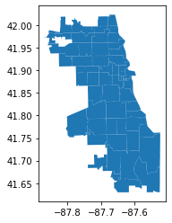

```python
vaxGeom.plot()
```

The map above shows Chicago by their separate zip coded areas.

### Decriptive Statistics and Histograms

```python
vaxGeom.describe()
```

|  | Population | Longitude | Latitude | Economic_Diversity_Index | Uninsured_residents | Uninsured_rate | Median_house_income | College_grad_rate | EP_POV | Unemp_rate | covidcases | covidcaseRate | covidvaxCompletionRate |
| --- | --- | --- | --- | --- | --- | --- | --- | --- | --- | --- | --- | --- | --- |
| count | 58.000000 | 58.000000 | 58.000000 | 58.000000 | 58.000000 | 58.000000 | 58.000000 | 58.000000 | 58.000000 | 58.000000 | 58.000000 | 58.000000 | 58.000000 |
| mean | 47659.275862 | -87.675044 | 41.864999 | 0.659595 | 4554.931034 | 8.189276 | 66271.937240 | 44.601930 | 17.844828 | 8.532143 | 4947.603448 | 10352.953138 | 40.434483 |
| std | 25788.399641 | 0.063835 | 0.094609 | 0.208461 | 4146.921250 | 4.485542 | 34247.829785 | 28.103178 | 9.866036 | 6.239307 | 3540.278327 | 3296.157063 | 15.153270 |
| min | 823.000000 | -87.827128 | 41.649434 | 0.000000 | 4.000000 | 0.486027 | 21190.138560 | 8.869751 | 1.500000 | 0.209205 | 81.000000 | 5904.085948 | 2.000000 |
| 25% | 29118.250000 | -87.712813 | 41.786628 | 0.537176 | 1347.750000 | 4.279931 | 39748.006320 | 19.749830 | 9.050000 | 3.773782 | 2704.500000 | 7936.387463 | 30.200000 |
| 50% | 46612.000000 | -87.662840 | 41.881282 | 0.773926 | 3385.500000 | 8.316864 | 59895.756080 | 38.799565 | 17.200000 | 6.640139 | 4043.500000 | 9803.537585 | 39.050000 |
| 75% | 66846.750000 | -87.629919 | 41.935898 | 0.801591 | 5870.000000 | 11.811531 | 90732.772640 | 72.716625 | 24.700000 | 11.195802 | 5904.750000 | 11738.324650 | 49.275000 |
| max | 110029.000000 | -87.552049 | 42.010019 | 0.824951 | 16389.000000 | 20.211874 | 183162.057000 | 95.190948 | 42.300000 | 27.164080 | 17371.000000 | 27446.300720 | 88.900000 |

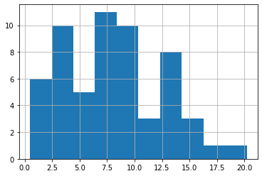

```python
vaxGeom["Uninsured_rate"].hist()
```

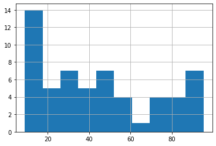

```python
vaxGeom["College_grad_rate"].hist()
```

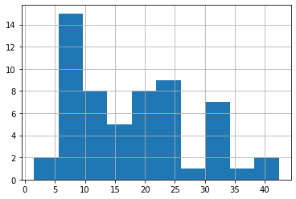

```python
vaxGeom["EP_POV"].hist()
```

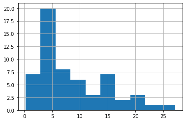

```python
vaxGeom["Unemp_rate"].hist()
```

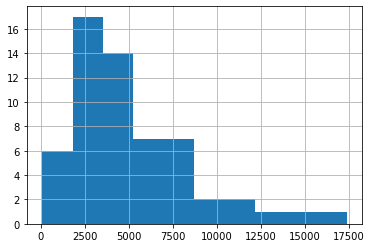

```python
vaxGeom["covidcases"].hist()
```

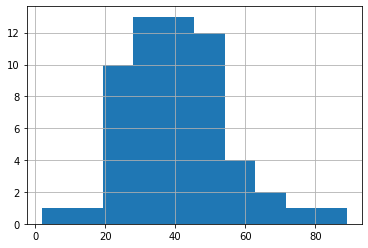

```python
vaxGeom["covidvaxCompletionRate"].hist()
```

The histograms show a clearer picture of the distribution of the variables. The uninsured rate of residents in Chicago and covid-19 vaccination completion rate shows a normal distribution. The poverty rate, poverty rate, and covid cases show a right skew in the data.

### Graduated color maps (choropleth)

Below chloropleth maps of Chicago zip code areas will be examined.

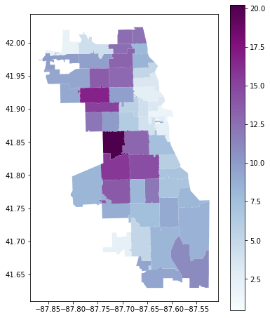

```python
vaxGeom.plot(column='Uninsured_rate', figsize=(6,8), legend=True, cmap='BuPu')
```

The chlorpleth map above shows that the Uninsured rate of residents are more centered around the West Side, Northwest Side indicating economic disparities and less acess to health insurance. The uninsured rate ranges from 10%-20%, which is a signicant portion of the population. Central Chicago and the North Side has an uninsured rate of about 4% or lower.

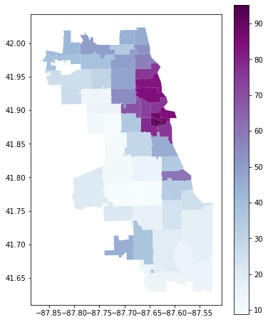

```python
vaxGeom.plot(column='College_grad_rate', figsize=(6,8), legend=True, cmap='BuPu')
```

The cholorpmeth above of the college grade rate shows a distinct difference between Central Chicago and the North Side, over the majority of the areas. This could affect income and economic disparities.

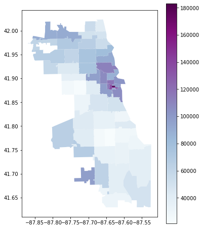

```python
vaxGeom.plot(column='Median_house_income', figsize=(6,8), legend=True, cmap='BuPu')
```

The chloropleth map above of the median house income shows that the income in Chicago is generally 100K or lower. In the areas surronding Central Chicago, the income is about 100K-160K.

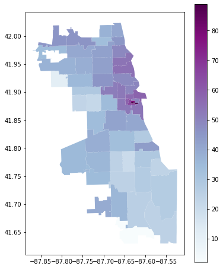

```python
vaxGeom.plot(column='covidvaxCompletionRate', figsize=(6,8), legend=True, cmap='BuPu')
```

The chloropleth map above shows that the covid vaccination completion rate is higher in Central Chicago, North Side, Far North SIde, Northwest side, and Far Southwestside, and gradually starts decreasing. The Far SouthEast Side, West Side, and South Side have signigicantly less vaccination comletion rates at about 20-30%.

### Correlation Matrix and Scatterplots

```python
corr_matrix = vaxGeom.corr()
corr_matrix
```

|  | Population | Longitude | Latitude | Economic_Diversity_Index | Uninsured_residents | Uninsured_rate | Median_house_income | College_grad_rate | EP_POV | Unemp_rate | covidcases | covidcaseRate | covidvaxCompletionRate |
| --- | --- | --- | --- | --- | --- | --- | --- | --- | --- | --- | --- | --- | --- |
| Population | 1.000000 | -0.254562 | 0.030910 | 0.544803 | 0.853578 | 0.615769 | -0.465075 | -0.483844 | 0.091373 | 0.099314 | 0.901108 | 0.003161 | -0.338629 |
| Longitude | -0.254562 | 1.000000 | -0.470073 | -0.280936 | -0.338011 | -0.330973 | 0.069255 | 0.300047 | 0.264477 | 0.209701 | -0.421938 | -0.322447 | 0.165172 |
| Latitude | 0.030910 | -0.470073 | 1.000000 | -0.221249 | 0.038198 | -0.005095 | 0.306904 | 0.410171 | -0.367435 | -0.626775 | -0.002031 | 0.027031 | 0.425276 |
| Economic_Diversity_Index | 0.544803 | -0.280936 | -0.221249 | 1.000000 | 0.563233 | 0.696481 | -0.897460 | -0.874461 | 0.530818 | 0.521056 | 0.506624 | 0.047454 | -0.805779 |
| Uninsured_residents | 0.853578 | -0.338011 | 0.038198 | 0.563233 | 1.000000 | 0.864384 | -0.499661 | -0.586716 | 0.216316 | 0.176768 | 0.910966 | 0.213484 | -0.333005 |
| Uninsured_rate | 0.615769 | -0.330973 | -0.005095 | 0.696481 | 0.864384 | 1.000000 | -0.656216 | -0.730473 | 0.443626 | 0.364802 | 0.686759 | 0.108474 | -0.502505 |
| Median_house_income | -0.465075 | 0.069255 | 0.306904 | -0.897460 | -0.499661 | -0.656216 | 1.000000 | 0.857706 | -0.777457 | -0.722967 | -0.403383 | 0.046047 | 0.847413 |
| College_grad_rate | -0.483844 | 0.300047 | 0.410171 | -0.874461 | -0.586716 | -0.730473 | 0.857706 | 1.000000 | -0.585234 | -0.694723 | -0.552233 | -0.072734 | 0.868183 |
| EP_POV | 0.091373 | 0.264477 | -0.367435 | 0.530818 | 0.216316 | 0.443626 | -0.777457 | -0.585234 | 1.000000 | 0.839019 | 0.037211 | -0.164102 | -0.577749 |
| Unemp_rate | 0.099314 | 0.209701 | -0.626775 | 0.521056 | 0.176768 | 0.364802 | -0.722967 | -0.694723 | 0.839019 | 1.000000 | 0.101267 | -0.137876 | -0.669292 |
| covidcases | 0.901108 | -0.421938 | -0.002031 | 0.506624 | 0.910966 | 0.686759 | -0.403383 | -0.552233 | 0.037211 | 0.101267 | 1.000000 | 0.287212 | -0.309963 |
| covidcaseRate | 0.003161 | -0.322447 | 0.027031 | 0.047454 | 0.213484 | 0.108474 | 0.046047 | -0.072734 | -0.164102 | -0.137876 | 0.287212 | 1.000000 | 0.087836 |
| covidvaxCompletionRate | -0.338629 | 0.165172 | 0.425276 | -0.805779 | -0.333005 | -0.502505 | 0.847413 | 0.868183 | -0.577749 | -0.669292 | -0.309963 | 0.087836 | 1.000000 |

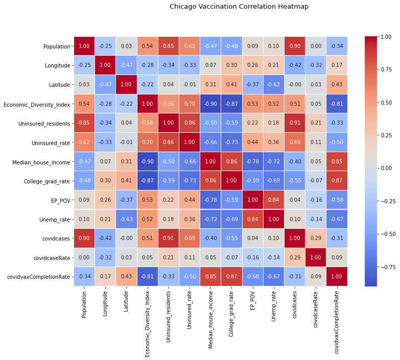

```python
# Creating a heatmap from the correlation matrix
plt.subplots(figsize=(12, 9))
sns.heatmap(round(corr_matrix,2), annot=True, cmap="coolwarm",fmt='.2f', linewidths=.05)
plt.suptitle('Chicago Vaccination Correlation Heatmap', fontsize=13)
```

Examing the variables with a high positive and negative correlation to vaccination completion rate.

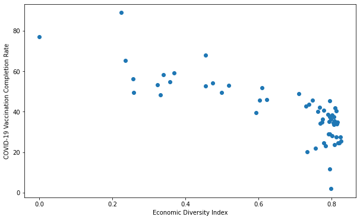

```python
fig, ax = plt.subplots(figsize=(10, 6))
ax.scatter(x = vaxGeom['Economic_Diversity_Index'], y = vaxGeom['covidvaxCompletionRate'])
plt.xlabel("Economic Diversity Index")
plt.ylabel("COVID-19 Vaccination Completion Rate")
```

This plot shows that as the economic diversity index increases, the covid vaccination completion rate decreases. This aligns with the -0.81 correlation value. Economic diversity measures how much an area has a mix of economic activities. It would be interesting to learn more about the reason for the low vaccination rate if it has any relation to EDI.

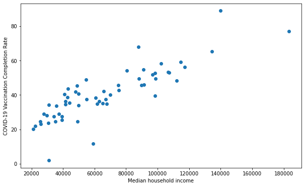

```python
fig, ax = plt.subplots(figsize=(10, 6))
ax.scatter(x = vaxGeom['Median_house_income'], y = vaxGeom['covidvaxCompletionRate'])
plt.xlabel("Median household income")
plt.ylabel("COVID-19 Vaccination Completion Rate")
```

The plot shows that as the median household income of Chicago residents increases, the vaccination completion increases. The correlation rate is 0.85, which is highly positive. So, the income of a household indicates a relationship between the two. Although it may not be the cause of someone getting vaccinated.

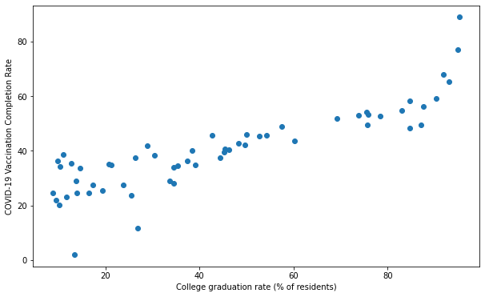

```python
fig, ax = plt.subplots(figsize=(10, 6))
ax.scatter(x = vaxGeom["College_grad_rate"], y = vaxGeom['covidvaxCompletionRate'])
plt.xlabel("College graduation rate (% of residents)")
plt.ylabel("COVID-19 Vaccination Completion Rate")
```

The plot shows that as the college graduation rate of Chicago residents increases, the vaccination completion increases. The correlation rate is 0.87, which is highly positive. So, the college graduation rate indicates a relationship between the two.

```python
# getting the rate variables
rate_cols = ["Uninsured_rate",
             "College_grad_rate",
             "EP_POV",
             "Unemp_rate",
             "covidvaxCompletionRate"]
```

```python
# crating a dataset of just the rates
vaxRates = vaxGeom[rate_cols]
vaxRates
```

|  | Uninsured_rate | College_grad_rate | EP_POV | Unemp_rate | covidvaxCompletionRate |
| --- | --- | --- | --- | --- | --- |
| 0 | 15.267188 | 13.737995 | 24.9 | 11.131880 | 28.9 |
| 1 | 8.823325 | 21.218274 | 12.8 | 11.217110 | 34.7 |
| 2 | 6.021158 | 34.479523 | 32.6 | 15.747832 | 28.1 |
| 3 | 1.625488 | 87.569093 | 7.0 | 2.067167 | 56.3 |
| 4 | 2.299695 | 45.246331 | 4.3 | 4.149924 | 39.6 |
| 5 | 9.958477 | 39.175641 | 7.5 | 3.796185 | 34.8 |
| 6 | 3.479243 | 82.955101 | 7.5 | 2.983766 | 54.7 |
| 7 | 12.624632 | 34.561599 | 23.5 | 6.909789 | 33.8 |
| 8 | 8.043963 | 52.737118 | 16.0 | 4.923555 | 45.4 |
| 9 | 2.543520 | 90.334268 | 8.4 | 1.503948 | 59.0 |
| 10 | 9.190979 | 26.886761 | 8.1 | 5.893455 | 11.8 |
| 11 | 9.404741 | 13.454209 | 30.4 | 19.673016 | 2.0 |
| 12 | 2.928870 | 87.029184 | 9.5 | 4.471341 | 49.4 |
| 13 | 1.222707 | 94.928335 | 1.5 | 0.209205 | 77.1 |
| 14 | 8.365019 | 95.190948 | 16.7 | 9.064748 | 88.9 |
| 15 | 0.486027 | 91.850594 | 20.8 | 7.512521 | 67.9 |
| 16 | 2.496998 | 75.784833 | 8.9 | 3.290810 | 53.3 |
| 17 | 4.137511 | 93.079238 | 8.1 | 2.103387 | 65.3 |
| 18 | 4.031424 | 78.340501 | 20.5 | 6.509217 | 52.6 |
| 19 | 13.080484 | 28.859464 | 19.1 | 6.771061 | 41.9 |
| 20 | 14.567661 | 14.525867 | 26.7 | 14.962552 | 33.5 |
| 21 | 3.337810 | 75.753811 | 10.0 | 3.156498 | 49.4 |
| 22 | 1.763785 | 84.678725 | 10.7 | 3.044036 | 58.3 |
| 23 | 6.260202 | 35.417802 | 30.7 | 9.919762 | 34.4 |
| 24 | 5.169888 | 75.441008 | 10.2 | 2.961941 | 54.1 |
| 25 | 2.663136 | 84.705791 | 8.2 | 2.591647 | 48.3 |
| 26 | 6.966021 | 60.146367 | 24.4 | 9.019711 | 43.7 |
| 27 | 7.478300 | 45.430363 | 23.1 | 5.285426 | 40.6 |
| 28 | 8.517569 | 17.334344 | 23.7 | 14.502868 | 27.4 |
| 29 | 12.960262 | 48.302302 | 10.3 | 3.497615 | 42.6 |
| 30 | 9.090166 | 23.841790 | 25.3 | 16.051238 | 27.6 |
| 31 | 7.644450 | 16.493346 | 24.8 | 16.406173 | 24.7 |
| 32 | 12.080537 | 10.197130 | 41.5 | 24.449421 | 20.2 |
| 33 | 5.574136 | 69.180476 | 11.2 | 2.504218 | 51.7 |
| 34 | 20.211874 | 10.334626 | 30.3 | 11.116172 | 34.2 |
| 35 | 9.983173 | 9.510496 | 42.3 | 20.077364 | 22.0 |
| 36 | 13.206227 | 49.676018 | 13.4 | 4.976847 | 42.1 |
| 37 | 12.486441 | 46.233834 | 25.0 | 5.464629 | 40.4 |
| 38 | 8.297127 | 19.423547 | 23.5 | 20.124495 | 25.5 |
| 39 | 13.863186 | 9.756980 | 17.7 | 14.799491 | 36.2 |
| 40 | 9.749244 | 38.423490 | 9.5 | 4.827476 | 40.1 |
| 41 | 5.151877 | 37.338343 | 14.2 | 10.348242 | 36.2 |
| 42 | 12.174236 | 11.751405 | 33.8 | 14.455476 | 23.1 |
| 43 | 2.099250 | 42.631460 | 6.2 | 2.505508 | 45.7 |
| 44 | 15.706216 | 10.965322 | 18.6 | 10.174051 | 38.5 |
| 45 | 11.004515 | 13.969238 | 18.0 | 8.385673 | 24.6 |
| 46 | 9.276502 | 26.379200 | 8.0 | 3.766314 | 37.5 |
| 47 | 8.208632 | 8.869751 | 31.9 | 27.164080 | 24.5 |
| 48 | 6.982231 | 33.600170 | 34.7 | 17.878745 | 29.1 |
| 49 | 8.336600 | 20.728678 | 8.8 | 7.997712 | 35.0 |
| 50 | 12.692234 | 44.358761 | 19.5 | 7.312590 | 37.6 |
| 51 | 4.368658 | 49.968362 | 7.2 | 4.771945 | 46.0 |
| 52 | 9.772706 | 54.216187 | 13.9 | 3.989144 | 45.6 |
| 53 | 8.242094 | 25.423993 | 31.9 | 15.974565 | 23.8 |
| 54 | 16.757820 | 12.711606 | 19.3 | 7.362892 | 35.3 |
| 55 | 8.348895 | 57.530972 | 18.9 | 4.226863 | 48.9 |
| 56 | 13.702528 | 30.346041 | 10.7 | 5.306808 | 38.4 |
| 57 | 4.250355 | 73.895342 | 8.8 | 3.574189 | 52.9 |

### Boxplot and Violinplot

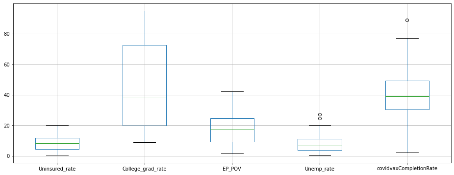

```python
vaxRates.boxplot(figsize=(16,6))
```

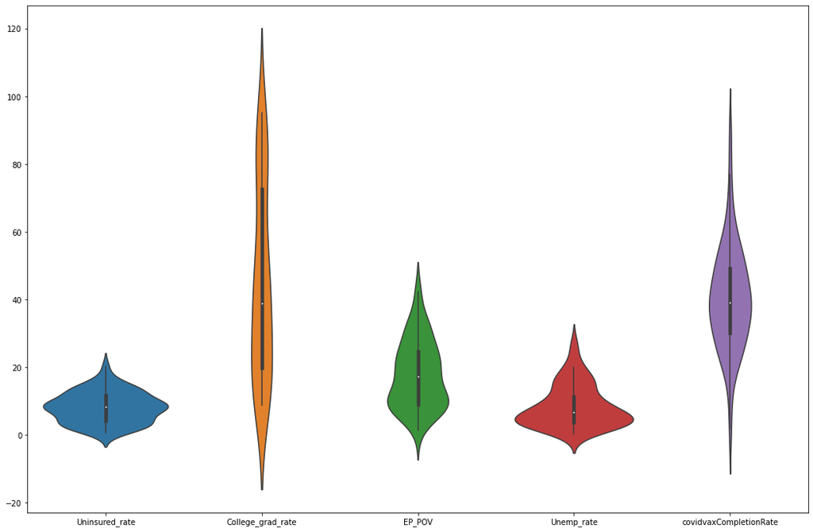

```python
fig, ax = plt.subplots(figsize=(18, 12))
sns.violinplot(figsize=(16,6), data = vaxRates)
```

The boxplot and violin plot give a general idea of what the range of the different rate variables look like. The uninsured rate of residents have a high concentration of values that range from 0%-18%. The college grade rate varies roughly equally from 0 to 100 percent. The poverty rate heavily ranges from 0 to 30 percent. The unemployment rate is highly concentrated from 0 to 15%. The covid vaccination completion rate ranges more highly from 20 to 60%.

## Wrangle Geographic Gata and Exploratory Spatial Data Analysis

```python
# import more libraries for ESDA techniques
import folium
from pysal.lib import weights
from pysal.explore import esda
```

```python
# read in data that includes FIPS code from Cook County data which can be matched with the zipcodes
svi = gpd.read_file(r"C:\Users\danya\OneDrive\Desktop\GEO 348 spatial data\data6B\svi_chi_4326.shp")
pd.set_option('display.max_columns', None)
svi.head()
```

|  | ST | STATE | ST_ABBR | STCNTY | COUNTY | FIPS | LOCATION | AREA_SQMI | E_TOTPOP | M_TOTPOP | E_HU | M_HU | E_HH | M_HH | E_POV | M_POV | E_UNEMP | M_UNEMP | E_PCI | M_PCI | E_NOHSDP | M_NOHSDP | E_AGE65 | M_AGE65 | E_AGE17 | M_AGE17 | E_DISABL | M_DISABL | E_SNGPNT | … |
| --- | --- | --- | --- | --- | --- | --- | --- | --- | --- | --- | --- | --- | --- | --- | --- | --- | --- | --- | --- | --- | --- | --- | --- | --- | --- | --- | --- | --- | --- | --- |
| 0 | 17 | ILLINOIS | IL | 17031 | Cook | 17031010100 | Census Tract 101, Cook County, Illinois | 0.146623 | 4522 | 529 | 2656 | 48 | 2316 | 181 | 1579 | 473 | 188 | 99 | 29482 | 4415 | 340 | 143 | 252 | 84 | 893 | 230 | 604 | 314 | 291 | … |
| 1 | 17 | ILLINOIS | IL | 17031 | Cook | 17031010201 | Census Tract 102.01, Cook County, Illinois | 0.194775 | 7039 | 804 | 2984 | 101 | 2688 | 156 | 2588 | 906 | 243 | 143 | 24590 | 6291 | 974 | 429 | 464 | 195 | 1760 | 495 | 995 | 332 | 253 | … |
| 2 | 17 | ILLINOIS | IL | 17031 | Cook | 17031010202 | Census Tract 102.02, Cook County, Illinois | 0.135814 | 2852 | 291 | 1256 | 33 | 1102 | 72 | 467 | 192 | 95 | 60 | 20228 | 2428 | 408 | 124 | 382 | 84 | 537 | 157 | 317 | 74 | 81 | … |
| 3 | 17 | ILLINOIS | IL | 17031 | Cook | 17031010300 | Census Tract 103, Cook County, Illinois | 0.182247 | 6650 | 514 | 3399 | 70 | 3037 | 188 | 916 | 316 | 166 | 121 | 34268 | 7057 | 602 | 208 | 1247 | 182 | 977 | 282 | 688 | 205 | 100 | … |
| 4 | 17 | ILLINOIS | IL | 17031 | Cook | 17031010400 | Census Tract 104, Cook County, Illinois | 0.211878 | 5153 | 609 | 2186 | 111 | 1938 | 160 | 694 | 272 | 215 | 118 | 22526 | 2894 | 86 | 89 | 341 | 142 | 568 | 297 | 497 | 164 | 78 | … |

```python
# Taking the columns to be used
svi = svi[['FIPS','EP_POV','geometry']].copy()
print(svi.head())
print(svi.crs)
```

```
          FIPS  EP_POV                                           geometry
0  17031010100    35.8  POLYGON ((-87.67720 42.02295, -87.67008 42.022...
1  17031010201    36.8  POLYGON ((-87.68466 42.01949, -87.68045 42.019...
2  17031010202    18.5  POLYGON ((-87.67686 42.01942, -87.67339 42.019...
3  17031010300    16.1  POLYGON ((-87.67134 42.01938, -87.66950 42.019...
4  17031010400    19.1  POLYGON ((-87.66346 42.01284, -87.66133 42.012...
epsg:4326
```

```python
# creating a copy of the vaxGEom dataset to be used for ESDA
vaxGeom2 = vaxGeom.copy()
vaxGeom2.head()
```

|  | GEOID10 | geometry | Population | Longitude | Latitude | Economic_Diversity_Index | Uninsured_residents | Uninsured_rate | Median_house_income | College_grad_rate | EP_POV | Unemp_rate | covidcases | covidcaseRate | covidvaxCompletionRate |
| --- | --- | --- | --- | --- | --- | --- | --- | --- | --- | --- | --- | --- | --- | --- | --- |
| 0 | 60651 | POLYGON ((-87.77559 41.90875, -87.77498 41.908... | 63492.0 | -87.740857 | 41.902093 | 0.793992 | 9691.0 | 15.267188 | 37253.44560 | 13.737995 | 24.9 | 11.131880 | 7963.0 | 13067.379960 | 28.9 |
| 1 | 60652 | POLYGON ((-87.74205 41.77113, -87.74182 41.771... | 43447.0 | -87.714795 | 41.747932 | 0.815656 | 3816.0 | 8.823325 | 67613.73664 | 21.218274 | 12.8 | 11.217110 | 5409.0 | 12776.058770 | 34.7 |
| 2 | 60653 | POLYGON ((-87.62623 41.81469, -87.62590 41.814... | 33154.0 | -87.605965 | 41.819965 | 0.801693 | 1975.0 | 6.021158 | 29734.85776 | 34.479523 | 32.6 | 15.747832 | 2748.0 | 8853.663251 | 28.1 |
| 3 | 60654 | POLYGON ((-87.64775 41.89640, -87.64764 41.896... | 20022.0 | -87.637268 | 41.892282 | 0.255976 | 325.0 | 1.625488 | 117141.54940 | 87.569093 | 7.0 | 2.067167 | 2091.0 | 12872.445210 | 56.3 |
| 4 | 60655 | POLYGON ((-87.73973 41.69089, -87.73949 41.690... | 28569.0 | -87.703776 | 41.694776 | 0.592940 | 657.0 | 2.299695 | 98322.12816 | 45.246331 | 4.3 | 4.149924 | 3491.0 | 12458.068660 | 39.6 |

```python
# checking the CRS
vaxGeom2.crs
```

```
<Geographic 2D CRS: EPSG:4269>
Name: NAD83
Axis Info [ellipsoidal]:
- Lat[north]: Geodetic latitude (degree)
- Lon[east]: Geodetic longitude (degree)
Area of Use:
- name: North America - onshore and offshore: Canada - Alberta; British Columbia; Manitoba; New Brunswick; Newfoundland and Labrador; Northwest Territories; Nova Scotia; Nunavut; Ontario; Prince Edward Island; Quebec; Saskatchewan; Yukon. Puerto Rico. United States (USA) - Alabama; Alaska; Arizona; …
- bounds: (167.65, 14.92, -47.74, 86.46)
Datum: North American Datum 1983
- Ellipsoid: GRS 1980
- Prime Meridian: Greenwich
```

```python
# converting the CRS to 4326 to match up with svi shp file
vaxGeom2 = vaxGeom2.to_crs('EPSG:4326')
vaxGeom2.crs
```

```
<Geographic 2D CRS: EPSG:4326>
Name: WGS 84
Axis Info [ellipsoidal]:
- Lat[north]: Geodetic latitude (degree)
- Lon[east]: Geodetic longitude (degree)
Area of Use:
- name: World.
- bounds: (-180.0, -90.0, 180.0, 90.0)
Datum: World Geodetic System 1984
- Ellipsoid: WGS 84
- Prime Meridian: Greenwich
```

```python
# checking geometry column
vaxGeom2.head()
```

|  | GEOID10 | geometry | Population | Longitude | Latitude | Economic_Diversity_Index | Uninsured_residents | Uninsured_rate | Median_house_income | College_grad_rate | EP_POV | Unemp_rate | covidcases | covidcaseRate | covidvaxCompletionRate |
| --- | --- | --- | --- | --- | --- | --- | --- | --- | --- | --- | --- | --- | --- | --- | --- |
| 0 | 60651 | POLYGON ((-87.77559 41.90875, -87.77498 41.908... | 63492.0 | -87.740857 | 41.902093 | 0.793992 | 9691.0 | 15.267188 | 37253.44560 | 13.737995 | 24.9 | 11.131880 | 7963.0 | 13067.379960 | 28.9 |
| 1 | 60652 | POLYGON ((-87.74205 41.77113, -87.74182 41.771... | 43447.0 | -87.714795 | 41.747932 | 0.815656 | 3816.0 | 8.823325 | 67613.73664 | 21.218274 | 12.8 | 11.217110 | 5409.0 | 12776.058770 | 34.7 |
| 2 | 60653 | POLYGON ((-87.62623 41.81469, -87.62590 41.814... | 33154.0 | -87.605965 | 41.819965 | 0.801693 | 1975.0 | 6.021158 | 29734.85776 | 34.479523 | 32.6 | 15.747832 | 2748.0 | 8853.663251 | 28.1 |
| 3 | 60654 | POLYGON ((-87.64775 41.89640, -87.64764 41.896... | 20022.0 | -87.637268 | 41.892282 | 0.255976 | 325.0 | 1.625488 | 117141.54940 | 87.569093 | 7.0 | 2.067167 | 2091.0 | 12872.445210 | 56.3 |
| 4 | 60655 | POLYGON ((-87.73973 41.69089, -87.73949 41.690... | 28569.0 | -87.703776 | 41.694776 | 0.592940 | 657.0 | 2.299695 | 98322.12816 | 45.246331 | 4.3 | 4.149924 | 3491.0 | 12458.068660 | 39.6 |

```python
# merge on common attribute ep_pov to "new" geodataframe
new = pd.merge(svi, vaxGeom2, how ="inner", on = ["EP_POV"])
new.info()
```

```
<class 'geopandas.geodataframe.GeoDataFrame'>
Int64Index: 147 entries, 0 to 146
Data columns (total 17 columns):
 #   Column                    Non-Null Count  Dtype
---  ------                    --------------  -----
 0   FIPS                      147 non-null    object
 1   EP_POV                    147 non-null    float64
 2   geometry_x                147 non-null    geometry
 3   GEOID10                   147 non-null    object
 4   geometry_y                147 non-null    geometry
 5   Population                147 non-null    float64
 6   Longitude                 147 non-null    float64
 7   Latitude                  147 non-null    float64
 8   Economic_Diversity_Index  147 non-null    float64
 9   Uninsured_residents       147 non-null    float64
 10  Uninsured_rate            147 non-null    float64
 11  Median_house_income       147 non-null    float64
 12  College_grad_rate         147 non-null    float64
 13  Unemp_rate                147 non-null    float64
 14  covidcases                147 non-null    float64
 15  covidcaseRate             147 non-null    float64
 16  covidvaxCompletionRate    147 non-null    float64
dtypes: float64(13), geometry(2), object(2)
memory usage: 20.7+ KB
```

```python
new.crs
```

```
<Geographic 2D CRS: EPSG:4326>
Name: WGS 84
Axis Info [ellipsoidal]:
- Lat[north]: Geodetic latitude (degree)
- Lon[east]: Geodetic longitude (degree)
Area of Use:
- name: World.
- bounds: (-180.0, -90.0, 180.0, 90.0)
Datum: World Geodetic System 1984
- Ellipsoid: WGS 84
- Prime Meridian: Greenwich
```

```python
# make a copy of "new" and save to "gdf"
# create new column of geometry which will save the geometry polygon from the chicago zip code areas
# then drop geometry x and y
gdf = new.copy()
gdf["geometry"] = gdf["geometry_y"]
gdf = gdf.drop(columns = ["geometry_y","geometry_x"])
gdf.head()
```

|  | FIPS | EP_POV | GEOID10 | Population | Longitude | Latitude | Economic_Diversity_Index | Uninsured_residents | Uninsured_rate | Median_house_income | College_grad_rate | Unemp_rate | covidcases | covidcaseRate | covidvaxCompletionRate | geometry |
| --- | --- | --- | --- | --- | --- | --- | --- | --- | --- | --- | --- | --- | --- | --- | --- | --- |
| 0 | 17031010400 | 19.1 | 60608 | 80059.0 | -87.670664 | 41.846880 | 0.808958 | 9267.0 | 13.080484 | 47943.19056 | 28.859464 | 6.771061 | 8114.0 | 10277.130410 | 41.9 | POLYGON ((-87.70291 41.83258, -87.70268 41.832... |
| 1 | 17031251000 | 19.1 | 60608 | 80059.0 | -87.670664 | 41.846880 | 0.808958 | 9267.0 | 13.080484 | 47943.19056 | 28.859464 | 6.771061 | 8114.0 | 10277.130410 | 41.9 | POLYGON ((-87.70291 41.83258, -87.70268 41.832... |
| 2 | 17031660800 | 19.1 | 60608 | 80059.0 | -87.670664 | 41.846880 | 0.808958 | 9267.0 | 13.080484 | 47943.19056 | 28.859464 | 6.771061 | 8114.0 | 10277.130410 | 41.9 | POLYGON ((-87.70291 41.83258, -87.70268 41.832... |
| 3 | 17031841200 | 19.1 | 60608 | 80059.0 | -87.670664 | 41.846880 | 0.808958 | 9267.0 | 13.080484 | 47943.19056 | 28.859464 | 6.771061 | 8114.0 | 10277.130410 | 41.9 | POLYGON ((-87.70291 41.83258, -87.70268 41.832... |
| 4 | 17031010600 | 24.4 | 60615 | 40590.0 | -87.596288 | 41.801647 | 0.737433 | 2825.0 | 6.966021 | 43108.03664 | 60.146367 | 9.019711 | 2429.0 | 5904.085948 | 43.7 | POLYGON ((-87.62603 41.80742, -87.62571 41.807... |

```python
# There are duplicate values of GEOId10 which is the zipcodes, as well as the FIPS so the duplicates need to be removed.
# There are currentyl 147 entries, which will decrase when the duplicates are removed.
gdf.info()
```

```
<class 'geopandas.geodataframe.GeoDataFrame'>
Int64Index: 147 entries, 0 to 146
Data columns (total 16 columns):
 #   Column                    Non-Null Count  Dtype
---  ------                    --------------  -----
 0   FIPS                      147 non-null    object
 1   EP_POV                    147 non-null    float64
 2   GEOID10                   147 non-null    object
 3   Population                147 non-null    float64
 4   Longitude                 147 non-null    float64
 5   Latitude                  147 non-null    float64
 6   Economic_Diversity_Index  147 non-null    float64
 7   Uninsured_residents       147 non-null    float64
 8   Uninsured_rate            147 non-null    float64
 9   Median_house_income       147 non-null    float64
 10  College_grad_rate         147 non-null    float64
 11  Unemp_rate                147 non-null    float64
 12  covidcases                147 non-null    float64
 13  covidcaseRate             147 non-null    float64
 14  covidvaxCompletionRate    147 non-null    float64
 15  geometry                  147 non-null    geometry
dtypes: float64(13), geometry(1), object(2)
memory usage: 19.5+ KB
```

```python
# drop duplicates of GEO10
gdf = gdf.drop_duplicates(subset='GEOID10', keep="last")
gdf.info()
```

```
<class 'geopandas.geodataframe.GeoDataFrame'>
Int64Index: 52 entries, 3 to 146
Data columns (total 16 columns):
 #   Column                    Non-Null Count  Dtype
---  ------                    --------------  -----
 0   FIPS                      52 non-null     object
 1   EP_POV                    52 non-null     float64
 2   GEOID10                   52 non-null     object
 3   Population                52 non-null     float64
 4   Longitude                 52 non-null     float64
 5   Latitude                  52 non-null     float64
 6   Economic_Diversity_Index  52 non-null     float64
 7   Uninsured_residents       52 non-null     float64
 8   Uninsured_rate            52 non-null     float64
 9   Median_house_income       52 non-null     float64
 10  College_grad_rate         52 non-null     float64
 11  Unemp_rate                52 non-null     float64
 12  covidcases                52 non-null     float64
 13  covidcaseRate             52 non-null     float64
 14  covidvaxCompletionRate    52 non-null     float64
 15  geometry                  52 non-null     geometry
dtypes: float64(13), geometry(1), object(2)
memory usage: 6.9+ KB
```

```python
#drop duplicates of FIPS (cannot be duplicates when creating weights)
gdf = gdf.drop_duplicates(subset='FIPS', keep="last")
gdf.info()
```

```
<class 'geopandas.geodataframe.GeoDataFrame'>
Int64Index: 46 entries, 3 to 146
Data columns (total 16 columns):
 #   Column                    Non-Null Count  Dtype
---  ------                    --------------  -----
 0   FIPS                      46 non-null     object
 1   EP_POV                    46 non-null     float64
 2   GEOID10                   46 non-null     object
 3   Population                46 non-null     float64
 4   Longitude                 46 non-null     float64
 5   Latitude                  46 non-null     float64
 6   Economic_Diversity_Index  46 non-null     float64
 7   Uninsured_residents       46 non-null     float64
 8   Uninsured_rate            46 non-null     float64
 9   Median_house_income       46 non-null     float64
 10  College_grad_rate         46 non-null     float64
 11  Unemp_rate                46 non-null     float64
 12  covidcases                46 non-null     float64
 13  covidcaseRate             46 non-null     float64
 14  covidvaxCompletionRate    46 non-null     float64
 15  geometry                  46 non-null     geometry
dtypes: float64(13), geometry(1), object(2)
memory usage: 6.1+ KB
```

```python
# Index is set to "FIPS" without dropping column
# "FIPS" will be identifier in constructing spatial weights
gdf = gdf.set_index('FIPS',drop=False)
gdf.head()
```

| FIPS | FIPS | EP_POV | GEOID10 | Population | Longitude | Latitude | Economic_Diversity_Index | Uninsured_residents | Uninsured_rate | Median_house_income | College_grad_rate | Unemp_rate | covidcases | covidcaseRate | covidvaxCompletionRate | geometry |
| --- | --- | --- | --- | --- | --- | --- | --- | --- | --- | --- | --- | --- | --- | --- | --- | --- |
| 17031841200 | 17031841200 | 19.1 | 60608 | 80059.0 | -87.670664 | 41.846880 | 0.808958 | 9267.0 | 13.080484 | 47943.19056 | 28.859464 | 6.771061 | 8114.0 | 10277.130410 | 41.9 | POLYGON ((-87.70291 41.83258, -87.70268 41.832... |
| 17031843200 | 17031843200 | 24.4 | 60615 | 40590.0 | -87.596288 | 41.801647 | 0.737433 | 2825.0 | 6.966021 | 43108.03664 | 60.146367 | 9.019711 | 2429.0 | 5904.085948 | 43.7 | POLYGON ((-87.62603 41.80742, -87.62571 41.807... |
| 17031842000 | 17031842000 | 20.8 | 60604 | 823.0 | -87.628461 | 41.878095 | 0.454661 | 4.0 | 0.486027 | 87742.36000 | 91.850594 | 7.512521 | 115.0 | 27446.300720 | 67.9 | POLYGON ((-87.63376 41.87925, -87.63375 41.879... |
| 17031191302 | 17031191302 | 14.2 | 60643 | 48887.0 | -87.663267 | 41.700273 | 0.775069 | 2500.0 | 5.151877 | 62764.23792 | 37.338343 | 10.348242 | 4562.0 | 8952.646349 | 36.2 | MULTIPOLYGON (((-87.64714 41.66134, -87.64713 ... |
| 17031020902 | 17031020902 | 26.7 | 60609 | 60939.0 | -87.656935 | 41.812680 | 0.805879 | 8850.0 | 14.567661 | 35721.42096 | 14.525867 | 14.962552 | 7328.0 | 11742.648830 | 33.5 | POLYGON ((-87.68731 41.82841, -87.68715 41.828... |

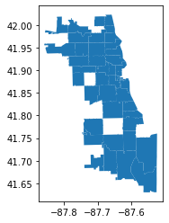

```python
# examine plot again to see how much is missing in new chicago zip coded areas
gdf.plot()
```

```python
# construct spatial weights object based on Queen method
w = weights.Queen.from_dataframe(gdf,idVariable='FIPS')
w
```

```
<pysal.lib.weights.contiguity.Queen at 0x2166fa87880>
```

```python
mc_x = gdf.geometry.centroid.x.mean()
mc_y = gdf.geometry.centroid.y.mean()
print(mc_x,mc_y)
```

```
-87.67101126376492 41.871036955565
```

```python
# creates an interacive map that shows zip code areas
m = folium.Map(location=[mc_y,mc_x],zoom_start=12,tiles='cartodbpositron')
folium.GeoJson(gdf).add_to(m)
m
```

Make this Notebook Trusted to load map: File -> Trust Notebook

[interactive chart not shown]

```python
# make a copy of gdf data into gdfSL
gdfSL = gdf.copy()
```

```python
# row standardize spatial weights using transform
w.transform = 'R'
```

```python
# spatial lag of unisured rate for each observation
uninsurSL = weights.lag_spatial(w,gdfSL.Uninsured_rate)
gdfSL['uninsurSL'] = uninsurSL
```

```
(-87.87564514999997, -87.50689984999998, 41.6102497, 42.04310629999999)
```

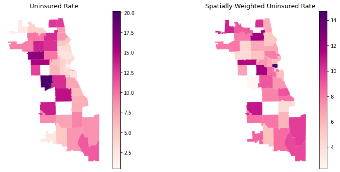

```python
# plotting Uninsured_rate and its spatial lag
f,axes=plt.subplots(1,2,figsize=(14,6))

gdfSL.plot(column='Uninsured_rate',cmap='RdPu',ax=axes[0],legend=True)
gdfSL.plot(column='uninsurSL',cmap='RdPu',ax=axes[1],legend=True)
axes[0].set_title("Uninsured Rate",fontsize=13)
axes[1].set_title("Spatially Weighted Uninsured Rate",fontsize=13)
axes[0].axis("off")
axes[1].axis("off")
```

The spatially weighted uninsured rate map shows that there are similar areas with the uninsured rate. but with different levels.

```python
# Poverty rate of unisured rate for each observation
povSL = weights.lag_spatial(w,gdfSL.EP_POV)
gdfSL['povSL'] = povSL
```

```
(-87.87564514999997, -87.50689984999998, 41.6102497, 42.04310629999999)
```

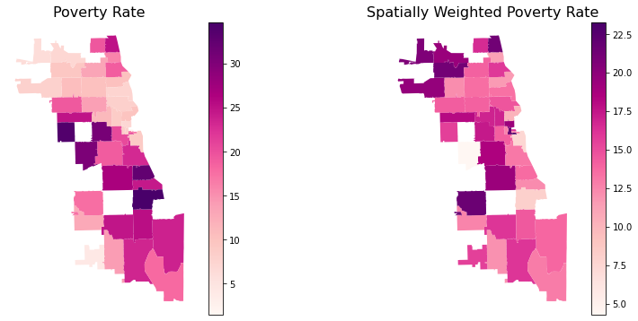

```python
f,axes=plt.subplots(1,2,figsize=(14,6))

gdfSL.plot(column='EP_POV',cmap='RdPu',ax=axes[0],legend=True)
gdfSL.plot(column='povSL',cmap='RdPu',ax=axes[1],legend=True)
axes[0].set_title("Poverty Rate",fontsize=16)
axes[1].set_title("Spatially Weighted Poverty Rate",fontsize=16)
axes[0].axis("off")
axes[1].axis("off")
```

The poverty rate is similar between the spatially weighted map and not, eith the exception of the area to the North. On the left, it is light yellow, so low poverty rates, and on the right, it shows it is higher.

```python
# unemployment rate spatial lag
unempSL = weights.lag_spatial(w,gdfSL.Unemp_rate)
gdfSL['unempSL'] = unempSL
```

```
(-87.87564514999997, -87.50689984999998, 41.6102497, 42.04310629999999)
```

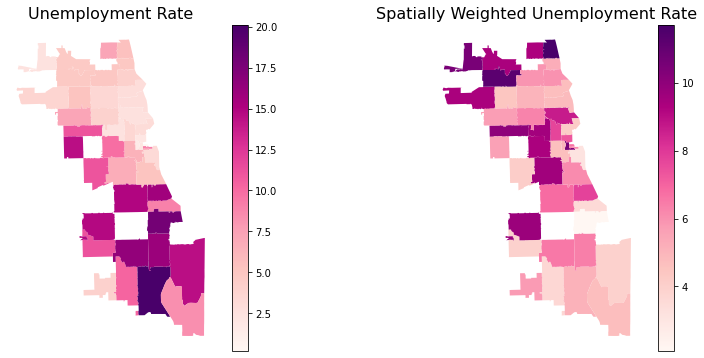

```python
f,axes=plt.subplots(1,2,figsize=(14,6))

gdfSL.plot(column='Unemp_rate',cmap='RdPu',ax=axes[0],legend=True)
gdfSL.plot(column='unempSL',cmap='RdPu',ax=axes[1],legend=True)
axes[0].set_title("Unemployment Rate",fontsize=16)
axes[1].set_title("Spatially Weighted Unemployment Rate",fontsize=16)
axes[0].axis("off")
axes[1].axis("off")
```

The spatially unemployed rate map shows that there are different areas that the unemployment rate affects geographically, including the general areas like, Far North Side, Northwest Side, West Side. However, the levels are measured differently.

```python
# college graduation spatial lag
gradSL = weights.lag_spatial(w,gdfSL.College_grad_rate)
gdfSL['gradSL'] = gradSL
```

```
(-87.87564514999997, -87.50689984999998, 41.6102497, 42.04310629999999)
```

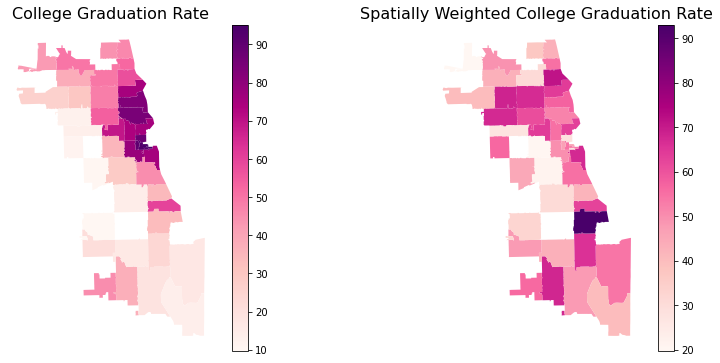

```python
f,axes=plt.subplots(1,2,figsize=(14,6))

gdfSL.plot(column='College_grad_rate',cmap='RdPu',ax=axes[0],legend=True)
gdfSL.plot(column='gradSL',cmap='RdPu',ax=axes[1],legend=True)
axes[0].set_title("College Graduation Rate",fontsize=16)
axes[1].set_title("Spatially Weighted College Graduation Rate",fontsize=16)
axes[0].axis("off")
axes[1].axis("off")
```

The college graduation rate map shows that it is similar across the different areas in the spatially weighted map.

```python
# covid vaccination completeion rate spatial lag  each observation
vaxSL = weights.lag_spatial(w,gdfSL.covidvaxCompletionRate)
gdfSL['vaxSL'] = vaxSL
```

```
(-87.87564514999997, -87.50689984999998, 41.6102497, 42.04310629999999)
```

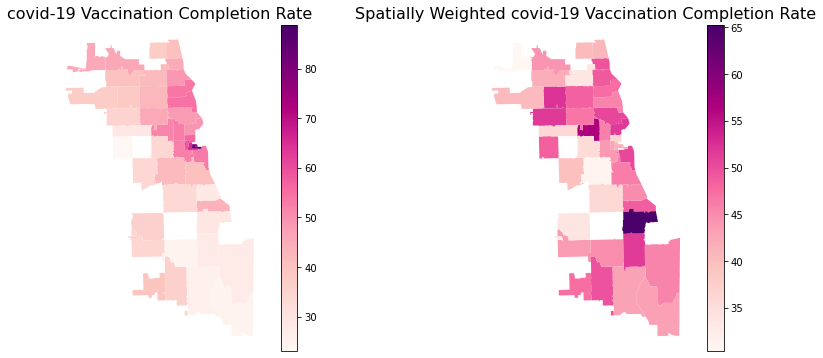

```python
f,axes=plt.subplots(1,2,figsize=(14,6))

gdfSL.plot(column='covidvaxCompletionRate',cmap='RdPu',ax=axes[0],legend=True)
gdfSL.plot(column='vaxSL',cmap='RdPu',ax=axes[1],legend=True)
axes[0].set_title("covid-19 Vaccination Completion Rate",fontsize=16)
axes[1].set_title("Spatially Weighted covid-19 Vaccination Completion Rate",fontsize=16)
axes[0].axis("off")
axes[1].axis("off")
```

The spatially weighted covid-19 vaccination completion rate shows that there are more locations that have vaccination completion rates that are high in areas including, Far Southwest Side, Northwest Side, Central.

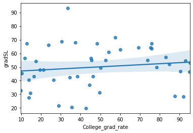

```python
# Moran's plot College graduation rate
# spatial lag in y against local observed values in x
sns.regplot(x='College_grad_rate',y='gradSL',data=gdfSL)
```

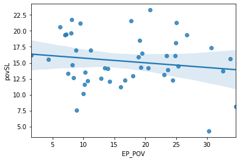

```python
# poverty rate moran's plot
sns.regplot(x='EP_POV',y='povSL',data=gdfSL)
```

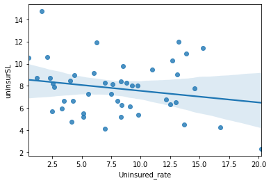

```python
# uninsured rate moran's plot
sns.regplot(x='Uninsured_rate',y='uninsurSL',data=gdfSL)
```

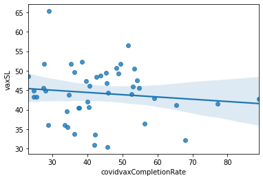

```python
# covid vax completion rate moran's plot
sns.regplot(x='covidvaxCompletionRate',y='vaxSL',data=gdfSL)
```

```python
# copy the data to gdfLM for local moran
gdfLM = gdfSL.copy()
```

```python
# calculate local moran's I
lm = esda.Moran_Local(gdfLM['covidvaxCompletionRate'],w)
lm
```

```
<pysal.explore.esda.moran.Moran_Local at 0x2166fd66370>
```

```python
# write results to gdfLM
gdfLM['LMZ_vaxRate'] = lm.z # z-score of Local Moran's I
gdfLM['LMP_vaxRate'] = lm.p_sim # p-value of Local Moran's I
gdfLM['LMQ_vaxRate'] = lm.q # quadrant type of Local Moran's I
```

```
(-87.87564514999997, -87.50689984999998, 41.61024969999999, 42.04310629999999)
```

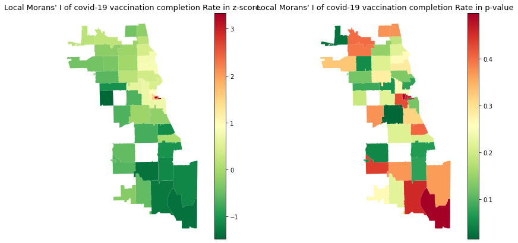

```python
# plot Local Moran's I in z-score and p-value
f,axes=plt.subplots(1,2,figsize=(14,7))

gdfLM.plot(column='LMZ_vaxRate',cmap='RdYlGn_r',ax=axes[0],legend=True)
gdfLM.plot(column='LMP_vaxRate',cmap='RdYlGn_r',ax=axes[1],legend=True)

axes[0].set_title("Local Morans' I of covid-19 vaccination completion Rate in z-score",fontsize=13)
axes[1].set_title("Local Morans' I of covid-19 vaccination completion Rate in p-value",fontsize=13)
axes[0].axis("off")
axes[1].axis("off")
```

Using z score and p-value for Local Moran's I will change how spatialy weighted the vaccination rates are as can be seen by the above graphs.

### Determing whether there are statistically signicant spatial clusters/outliers with the covid-19 vaccination rates.

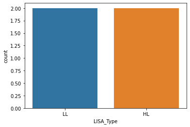

```python
# 'HH' if quadrant type is 1
# 'LH' if quadrant type is 2
# 'LH' if quadrant type is 3
# 'LH' if quadrant type is 4
cond_hh = (gdfLM['LMQ_vaxRate'] == 1) & (gdfLM['LMP_vaxRate'] <= 0.05)
cond_lh = (gdfLM['LMQ_vaxRate'] == 2) & (gdfLM['LMP_vaxRate'] <= 0.05)
cond_ll = (gdfLM['LMQ_vaxRate'] == 3) & (gdfLM['LMP_vaxRate'] <= 0.05)
cond_hl = (gdfLM['LMQ_vaxRate'] == 4) & (gdfLM['LMP_vaxRate'] <= 0.05)

gdfLM.loc[cond_hh,'LISA_Type'] = 'HH'
gdfLM.loc[cond_lh,'LISA_Type'] = 'LH'
gdfLM.loc[cond_ll,'LISA_Type'] = 'LL'
gdfLM.loc[cond_hl,'LISA_Type'] = 'HL'

# create a countplot to show where it falls into the quadtrant type
sns.countplot(x='LISA_Type',data=gdfLM)
```

```python
gdfLM.groupby(gdfLM['LISA_Type']).size()
```

```
LISA_Type
HL    2
LL    2
dtype: int64
```

There are just four statistically signicany clusters/outliers possibly because of the small amout of data

```python
# making an interactive LISA map from statistically significant clusters/outliers
lisa_series = gdfLM['LISA_Type'].dropna()
lisa_series
```

```
FIPS
17031841200    LL
17031842000    HL
17031140400    HL
17031836600    LL
Name: LISA_Type, dtype: object
```

```python
# print latitute and longitude
mc_x = gdfLM.geometry.centroid.x.mean()
mc_y = gdfLM.geometry.centroid.y.mean()
print(mc_x,mc_y)
```

```
-87.67101126376492 41.871036955565
```

```python
m = folium.Map(location=[mc_y,mc_x],zoom_start=10,tiles='cartodbpositron')

# set color palette for LL, HL, LH
lmq_c = {'LL':'blue','HL':'orange','LH':'lightskyblue'}

def style_function(feature):

    lmq_type = lisa_series.get(feature['properties']['FIPS'],None)
    if lmq_type is None:
        return {'fillOpacity':0.5, 'weight':0.5, 'fillColor':'gray', 'color':'white'}
    else:
        return {'fillOpacity':0.5, 'weight':0.5, 'fillColor':lmq_c[lmq_type], 'color':'white'}


tt = folium.GeoJsonTooltip(fields=['FIPS','covidvaxCompletionRate','LISA_Type'])

folium.GeoJson(gdfLM,style_function=style_function, tooltip=tt).add_to(m)

m
```

Make this Notebook Trusted to load map: File -> Trust Notebook

[interactive chart not shown]

With the interactive map, we can visualize where the 4 statistically significant spatial clusters/outliers are located for the covid vaccination completion rate.

It would be interesting to see how this changes with a different type of data, like the census tracts, which has more available points. However, the covid vaccination data was only available for the zipcodes on the Chicago health atlas website.

# Discussion

There are clear differences in unemployment rates, income levels, graduation rate, that differ between different areas in Chicago by the zipcode. The covid-19 vaccination completion rate also has significant differences between areas The spatial weights of this also shows a more detailed look into how the different socioeconomic factors differ in Chicago.

In the future, it would be interesting to see the vaccination sites in Chicago and how that looks with the different socioeconomic factors that were examined in this project. Additionally, if there is data that becomes available on the Chicago health atlas website that includes the covid data, there would be a lot more data points available from the census tracts or community areas.

(I tried to use the COVID-19 Vaccination Locations to create an interactive map colored by covid vaccination completion rates underneath. However, I ran into the dead kernel error when I was starting to run the lines. I included the screenshot in the zip folder. The data for that is from this website-> https://data.cityofchicago.org/Health-Human-Services/COVID-19-Vaccination-Locations-Map/4shi-izjg?referrer=embed)

## References

Lopez, G. (2021, June 2). The 6 reasons Americans aren't getting vaccinated. Vox. https://www.vox.com/2021/6/2/22463223/covid-19-vaccine-hesitancy-reasons-why.